# Analiza danych sprzedażowych

Marta Szymanska, Irena Skurat

2026-06-07

# Analiza danych sprzedażowych

## Opis danych

W projekcie wykorzystano dane ze zbioru Store Sales Time Series Forecasting dostępnego na platformie Kaggle.

Zbiór zawiera informacje o sprzedaży produktów w 54 sklepach, obejmujące datę sprzedaży, kategorię produktu, liczbę produktów objętych promocją oraz charakterystyki sklepów.

## Wczytanie danych

```r
sales <- load_sales_data(
  "data_raw/train.csv",
  "data_raw/stores.csv",
  "data_raw/holidays_events.csv"
)
```

## Walidacja danych

```r
validation <- validate_sales_ts(sales)

validation
```

```
## $missing_values
##          id        date   store_nbr      family       sales onpromotion
##           0           0           0           0           0           0
##        city       state        type     cluster
##           0           0           0           0
##
## $duplicates
## [1] 0
##
## $negative_sales
## [1] 0
##
## $invalid_dates
## [1] 0
##
## $date_gaps
## [1] 4
```

### Wyniki

Na podstawie przeprowadzonej walidacji stwierdzono:

- brak brakujących danych,
- brak duplikatów,
- brak ujemnych wartości sprzedaży,
- brak niepoprawnych dat,
- wykryto 4 przerwy w ciągu dat.

## Czyszczenie danych

```r
sales_clean <- clean_sales_ts(sales)

print(dim(sales_clean))
```

```
## [1] 3000888      10
```

Dane zostały posortowane chronologicznie, usunięto ewentualne duplikaty oraz przygotowano zbiór do dalszej analizy.

## Metryki biznesowe

```r
metrics <- compute_sales_metrics(sales_clean)

metrics
```

```
##   total_sales average_sales median_sales max_sales min_sales sd_sales
## 1  1073644952      357.7757           11    124717         0 1101.998
##   promotion_share
## 1        0.203716
```

## Wyniki analizy metryk biznesowych

Na podstawie danych sprzedażowych obliczono podstawowe wskaźniki biznesowe.

| Metryka | Wartość |
| --- | --- |
| Całkowita sprzedaż | 1 073 644 952 |
| Średnia sprzedaż | 357.78 |
| Mediana sprzedaży | 11 |
| Maksymalna sprzedaż | 124 717 |
| Minimalna sprzedaż | 0 |
| Odchylenie standardowe | 1101.998 |
| Udział promocji | 20.37% |

Interpretacja wyników wskazuje na znaczną zmienność sprzedaży pomiędzy obserwacjami. Mediana sprzedaży jest istotnie niższa od średniej, co sugeruje występowanie dużej liczby niskich wartości oraz nielicznych bardzo wysokich wartości sprzedaży.

### Wnioski

- Łączna sprzedaż przekroczyła 1 miliard jednostek.
- Rozkład sprzedaży jest silnie asymetryczny, ponieważ mediana (11) jest znacznie niższa od średniej (357.78).
- Występują bardzo wysokie wartości sprzedaży w wybranych okresach lub sklepach.
- Około 20% obserwacji dotyczyło produktów objętych promocją.
- Sprzedaż charakteryzuje się wysoką zmiennością, co potwierdza duże odchylenie standardowe.

## Wizualizacja trendów sprzedażowych

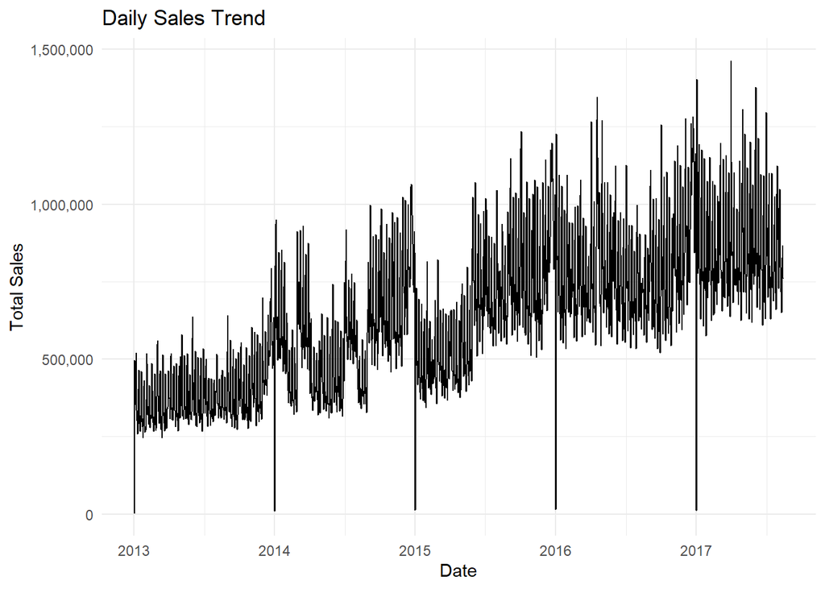

```r
plot_sales_trends(sales_clean)
```

Wykres wskazuje na wyraźny wzrost całkowitej sprzedaży w latach 2013–2017. Widoczne są również okresowe spadki sprzedaży oraz zwiększająca się zmienność wartości sprzedaży w czasie.

## Podsumowanie dla menedżera

```r
management_summary <- create_management_summary(sales_clean)

management_summary
```

```
##            metric     value
## 1      Best Store        44
## 2     Worst Store        52
## 3       Best City     Quito
## 4    Top Category GROCERY I
## 5   Average Sales    357.78
## 6 Promotion Share     20.37
```

### Interpretacja wyników

Na podstawie przeprowadzonej analizy:

- sklep nr 44 osiągnął najwyższą całkowitą sprzedaż,
- sklep nr 52 osiągnął najniższą całkowitą sprzedaż,
- najwyższą sprzedaż odnotowano w mieście Quito,
- kategorią generującą największą sprzedaż była GROCERY I,
- średnia wartość sprzedaży wyniosła 357.78,
- około 20.37% obserwacji dotyczyło produktów objętych promocją.

## Wpływ promocji na sprzedaż

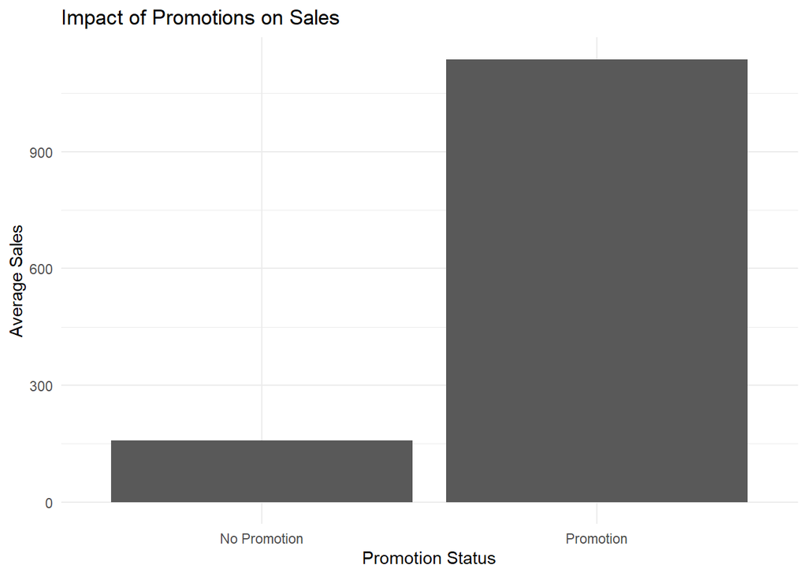

Promocje stanowią istotny element strategii sprzedażowej przedsiębiorstwa. Wykres przedstawia średnią sprzedaż dla produktów objętych promocją oraz nieobjętych promocją.

Widoczna różnica pomiędzy grupami wskazuje, że działania promocyjne wpływają na poziom sprzedaży i mogą stanowić skuteczne narzędzie zwiększania przychodów.

## Prognozowanie sprzedaży (ARIMA)

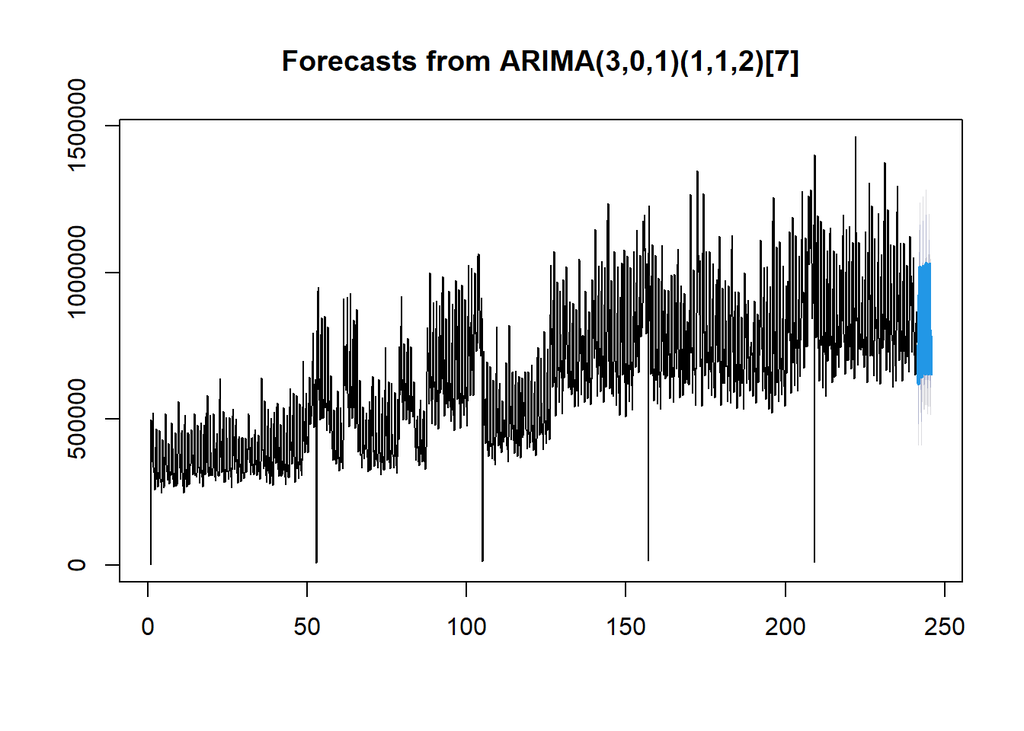

Model ARIMA został wykorzystany do prognozowania sprzedaży na kolejnych 30 okresów. Wyniki wskazują na utrzymanie stabilnego poziomu sprzedaży przy zachowaniu charakterystycznych tygodniowych wahań. Model automatycznie wykrył sezonowość siedmiodniową, co jest zgodne z charakterem danych detalicznych. Przedziały ufności rozszerzają się wraz z horyzontem prognozy, co odzwierciedla rosnącą niepewność prognoz długoterminowych.

## Prognozowanie sprzedaży (ETS)

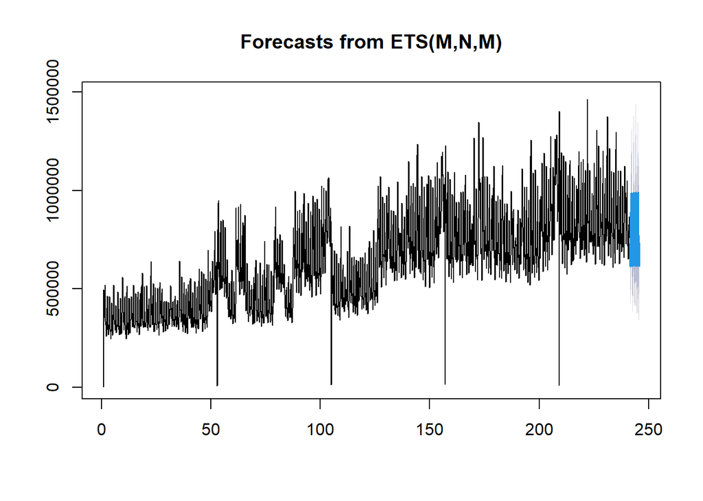

Dla porównania wykorzystano również model ETS (Exponential Smoothing). Model ten bazuje na metodzie wygładzania wykładniczego i pozwala prognozować przyszłe wartości szeregu czasowego na podstawie obserwowanych trendów i sezonowości.

Wyniki prognozy są zbliżone do modelu ARIMA, co zwiększa wiarygodność przewidywań dotyczących przyszłej sprzedaży.

## Porównanie metod prognozowania

W projekcie wykorzystano dwa modele prognozowania:

- ARIMA,
- ETS (Exponential Smoothing).

Oba modele wskazują na utrzymanie wysokiego poziomu sprzedaży w kolejnych okresach. Uzyskane prognozy są zbliżone, co świadczy o stabilności trendów występujących w danych sprzedażowych.

Zastosowanie dwóch niezależnych metod zwiększa wiarygodność prognoz oraz pozwala lepiej ocenić przyszłe wyniki sprzedażowe przedsiębiorstwa.

## Wnioski końcowe

W ramach projektu opracowano pakiet R umożliwiający kompleksową analizę szeregów czasowych danych sprzedażowych. Pakiet pozwala na automatyczne wczytywanie danych, ich walidację, czyszczenie, analizę oraz prognozowanie przyszłej sprzedaży.

Przeprowadzona analiza wykazała, że dane sprzedażowe charakteryzują się dużą zmiennością oraz wyraźnym trendem wzrostowym w badanym okresie. Największe wartości sprzedaży obserwowano w sklepach zlokalizowanych w Quito, a dominującą kategorią produktową była grupa GROCERY I.

Analiza wpływu promocji potwierdziła, że działania promocyjne mają istotny wpływ na poziom sprzedaży. Około 20% obserwacji dotyczyło produktów objętych promocją.

Do prognozowania wykorzystano dwa modele szeregów czasowych: ARIMA oraz ETS (Exponential Smoothing). Oba modele wygenerowały zbliżone prognozy, wskazując na utrzymanie wysokiego poziomu sprzedaży w kolejnych okresach. Zastosowanie dwóch niezależnych metod zwiększyło wiarygodność uzyskanych wyników.

Przygotowany pakiet może stanowić podstawę do dalszych analiz biznesowych oraz wspomagać proces podejmowania decyzji związanych z planowaniem sprzedaży.